# Tutorial 3: Linear regression

Forschungspraktikum I und II: Vergleichende Sozialforschung mit Mehrebenenmodellen in R

Dr. Christian Czymara (Sociology with Focus on Quantitative Methods for Social Research, Goethe University Frankfurt)

What predicts public support of income redistribution? In this tutorial, we will draw upon a reduced version of the European Social Survey 2008/09. We will have a look at three countries: Germany, Sweden, and the UK, representing a conservative, a social democratic, and a liberal welfare state.

## 1. Importing data

This time we will import the data from a so-called comma-separated values (CSV) file. This is one of the most used file type for storing and sharing data. The function we will need is `read.csv()`. This is part of base R, so we don’t need to install a package beforehand. Import the data and assign it to an object `ESS08` (to handle missing values correctly, add option `na.strings=c("","NA")` to `read.csv()`).

```r
setwd("C:/Users/czymara.local/PowerFolders/teaching/FoP HLM/_R/03_linear_regression")
```

```
## Error in setwd("C:/Users/czymara.local/PowerFolders/teaching/FoP HLM/_R/03_linear_regression"): kann Arbeitsverzeichnis nicht wechseln
```

```r
# load
ESS08 <- read.csv("ess08_prep.csv", na.strings=c("","NA"))
```

## 2. Data preparation

### a) Recoding outcome

Our variable of interest is `gincdif` (*“Government should reduce differences in income levels”*). What’s the scale of this item? How is the variable distributed? Recode this variable in descending order (i. e., *“disagree strongly”* becomes *“1 disagree strongly”*, *“disagree”* becomes *“2 disagree”* etc.).

```r
# original variable
table(ESS08$gincdif)
```

```
##
##                      agree             agree strongly
##                       3020                       1353
##                   disagree          disagree strongly
##                       1001                        157
## neither agree nor disagree
##                       1307
```

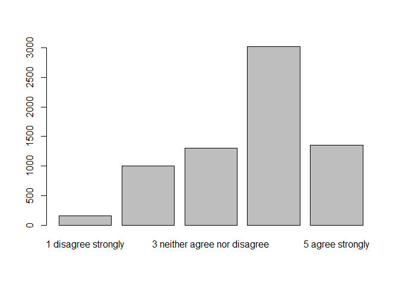

```r
# load dplyr for recording
library(dplyr)

# recode
ESS08$gincdif_rec <- recode(ESS08$gincdif,
       "disagree strongly" = "1 disagree strongly",
       "disagree" = "2 disagree",
       "neither agree nor disagree" = "3 neither agree nor disagree",
       "agree" = "4 agree",
       "agree strongly" = "5 agree strongly"
       )

# plot
barplot(table(ESS08$gincdif_rec))
```

### b) Make outcome continuous

Which type of variable is `gincdif`? We will treat this variable as continuous for didactical reasons. Thus, turn it into a numeric variable (hint: first convert to *factor*, then to *numeric*).

```r
typeof(ESS08$gincdif_rec)
```

```
## [1] "character"
```

```r
# make numeric
ESS08$gincdif_rec_num <- as.numeric(ESS08$gincdif_rec)

table(is.na(ESS08$gincdif_rec_num)) # makes problems when directly converting to numeric
```

```
##
## TRUE
## 6933
```

```r
ESS08$gincdif_rec_num <- NULL # didn't work, so remove

# next try
ESS08$gincdif_rec <- as.numeric(factor(ESS08$gincdif_rec))

table(is.na(ESS08$gincdif_rec))
```

```
##
## FALSE  TRUE
##  6838    95
```

```r
is.numeric(ESS08$gincdif_rec)
```

```
## [1] TRUE
```

### c) Nested models

We will later add gender (`gndr`), age (`agea`), and income (`hinctnta`) as control variables. How many respondents have a missing value on at least one of these variables (use `is.na()`)? To define our sample of analysis, remove all respondents who have a missing value on either of these three variables (listwise deletion, use `complete.cases()`).

```r
# Define relevant variables
modelVars <- c("gndr", "agea", "hinctnta")

# Check number of missings
table(is.na(ESS08$gndr) | is.na(ESS08$agea) | is.na(ESS08$hinctnta))
```

```
##
## FALSE  TRUE
##  6006   927
```

```r
# Alternatively
table(complete.cases(ESS08[, modelVars])) # remember indexing: [rows, columns]
```

```
##
## FALSE  TRUE
##   927  6006
```

```r
# Listwise deletion
ESS08 <- ESS08[complete.cases(ESS08[, modelVars]), ]

# Check again
table(is.na(ESS08$gndr) | is.na(ESS08$agea) | is.na(ESS08$hinctnta))
```

```
##
## FALSE
##  6006
```

## 3. Labor market status and support for income redistribution

### a) OLS model

Does welfare state support differ across the levels of labor market status (`mnactic`)? Use the `lm()` function to regress support for income redistribution on labor market status and interpret the results. Note that labor market status is a variable with multiple categories. Use those not in the labor force as the reference category. Assign the results to an object `model1`. How large is the difference compared to the unemployed? What about the differences between those in education and those not in the labor force?

```r
model1 <- lm(gincdif_rec ~ mnactic1 + mnactic2 + mnactic3, ESS08) # Using dummy variables for each category

model1 <- lm(gincdif_rec ~ factor(mnactic), ESS08) # using factor notation

model1 <- lm(gincdif_rec ~ relevel(factor(mnactic), ref = "not in labor force"), ESS08) # specifying the reference category

summary(model1)
```

```
##
## Call:
## lm(formula = gincdif_rec ~ relevel(factor(mnactic), ref = "not in labor force"),
##     data = ESS08)
##
## Residuals:
##     Min      1Q  Median      3Q     Max
## -3.0187 -0.5860  0.2458  0.4140  1.4140
##
## Coefficients:
##                                                                  Estimate
## (Intercept)                                                       3.75423
## relevel(factor(mnactic), ref = "not in labor force")in education -0.14527
## relevel(factor(mnactic), ref = "not in labor force")paid work    -0.16826
## relevel(factor(mnactic), ref = "not in labor force")unemployed    0.26443
##                                                                  Std. Error
## (Intercept)                                                         0.02274
## relevel(factor(mnactic), ref = "not in labor force")in education    0.06015
## relevel(factor(mnactic), ref = "not in labor force")paid work       0.02881
## relevel(factor(mnactic), ref = "not in labor force")unemployed      0.06628
##                                                                  t value
## (Intercept)                                                      165.128
## relevel(factor(mnactic), ref = "not in labor force")in education  -2.415
## relevel(factor(mnactic), ref = "not in labor force")paid work     -5.841
## relevel(factor(mnactic), ref = "not in labor force")unemployed     3.989
##                                                                  Pr(>|t|)
## (Intercept)                                                       < 2e-16 ***
## relevel(factor(mnactic), ref = "not in labor force")in education   0.0158 *
## relevel(factor(mnactic), ref = "not in labor force")paid work    5.45e-09 ***
## relevel(factor(mnactic), ref = "not in labor force")unemployed   6.71e-05 ***
## ---
## Signif. codes:  0 '***' 0.001 '**' 0.01 '*' 0.05 '.' 0.1 ' ' 1
##
## Residual standard error: 1.019 on 5930 degrees of freedom
##   (72 Beobachtungen als fehlend gelöscht)
## Multiple R-squared:  0.01144,    Adjusted R-squared:  0.01094
## F-statistic: 22.88 on 3 and 5930 DF,  p-value: 1.012e-14
```

### b) Adding control variables

Add gender (`gndr`), age (`agea`) and income (`hinctnta`) as control variables. Assign the results to an object `model2`. Is the effect of labor market status stable to the inclusion of these control variables?

```r
model2 <- lm(gincdif_rec ~ relevel(factor(mnactic), ref = "not in labor force") + gndr + agea + hinctnta, ESS08)

summary(model2)
```

```
##
## Call:
## lm(formula = gincdif_rec ~ relevel(factor(mnactic), ref = "not in labor force") +
##     gndr + agea + hinctnta, data = ESS08)
##
## Residuals:
##     Min      1Q  Median      3Q     Max
## -3.1885 -0.6875  0.2003  0.5631  2.0766
##
## Coefficients:
##                                                                    Estimate
## (Intercept)                                                       3.8415548
## relevel(factor(mnactic), ref = "not in labor force")in education -0.0125721
## relevel(factor(mnactic), ref = "not in labor force")paid work     0.0258199
## relevel(factor(mnactic), ref = "not in labor force")unemployed    0.2653242
## gndrmale                                                         -0.1557799
## agea                                                              0.0014280
## hinctntad - 9th decile                                           -0.3491521
## hinctntaf - 5th decile                                           -0.0835269
## hinctntah - 10th decile                                          -0.7711973
## hinctntaj - 1st decile                                            0.0049525
## hinctntak - 7th decile                                           -0.2644400
## hinctntam - 4th decile                                           -0.1165396
## hinctntap - 8th decile                                           -0.1999054
## hinctntar - 2nd decile                                            0.0287915
## hinctntas - 6th decile                                           -0.2106603
##                                                                  Std. Error
## (Intercept)                                                       0.0762335
## relevel(factor(mnactic), ref = "not in labor force")in education  0.0718138
## relevel(factor(mnactic), ref = "not in labor force")paid work     0.0365934
## relevel(factor(mnactic), ref = "not in labor force")unemployed    0.0694516
## gndrmale                                                          0.0261353
## agea                                                              0.0009796
## hinctntad - 9th decile                                            0.0591781
## hinctntaf - 5th decile                                            0.0582271
## hinctntah - 10th decile                                           0.0597554
## hinctntaj - 1st decile                                            0.0591987
## hinctntak - 7th decile                                            0.0567141
## hinctntam - 4th decile                                            0.0575646
## hinctntap - 8th decile                                            0.0574785
```

[output cut: 26 more lines]

```
## hinctntaf - 5th decile                                           0.151482
## hinctntah - 10th decile                                           < 2e-16 ***
## hinctntaj - 1st decile                                           0.933330
## hinctntak - 7th decile                                           3.19e-06 ***
## hinctntam - 4th decile                                           0.042963 *
## hinctntap - 8th decile                                           0.000509 ***
## hinctntar - 2nd decile                                           0.618018
## hinctntas - 6th decile                                           0.000341 ***
## ---
## Signif. codes:  0 '***' 0.001 '**' 0.01 '*' 0.05 '.' 0.1 ' ' 1
##
## Residual standard error: 0.9949 on 5919 degrees of freedom
##   (72 Beobachtungen als fehlend gelöscht)
## Multiple R-squared:  0.06001,    Adjusted R-squared:  0.05778
## F-statistic: 26.99 on 14 and 5919 DF,  p-value: < 2.2e-16
```

### c) Tables

A very nice way to create tables in R are the packages of [Daniel Lüdecke](https://github.com/strengejacke), like `sjPlot`. Install and load `sjPlot`. Then use its `tab_model` function to create a table for the models we estimated in 3.a) (`model1`) and 3.b) (`model2`).

```r
# install and load sjPlot
if(!require(sjPlot)){
    install.packages("sjPlot")
    library(sjPlot)
}

tab_model(model1, model2)
```

|  | gincdif rec |  |  | gincdif rec |  |  |
| --- | --- | --- | --- | --- | --- | --- |
| Predictors | Estimates | CI | p | Estimates | CI | p |
| (Intercept) | 3.75 | 3.71 – 3.80 | **<0.001** | 3.84 | 3.69 – 3.99 | **<0.001** |
| relevel(mnactic, ref = “not in labor force”)in education | -0.15 | -0.26 – -0.03 | **0.016** | -0.01 | -0.15 – 0.13 | 0.861 |
| relevel(mnactic, ref = “not in labor force”)paid work | -0.17 | -0.22 – -0.11 | **<0.001** | 0.03 | -0.05 – 0.10 | 0.480 |
| relevel(mnactic, ref = “not in labor force”)unemployed | 0.26 | 0.13 – 0.39 | **<0.001** | 0.27 | 0.13 – 0.40 | **<0.001** |
| gndr [male] |  |  |  | -0.16 | -0.21 – -0.10 | **<0.001** |
| agea |  |  |  | 0.00 | -0.00 – 0.00 | 0.145 |
| hinctnta [d - 9th decile] |  |  |  | -0.35 | -0.47 – -0.23 | **<0.001** |
| hinctnta [f - 5th decile] |  |  |  | -0.08 | -0.20 – 0.03 | 0.151 |
| hinctnta [h - 10th decile] |  |  |  | -0.77 | -0.89 – -0.65 | **<0.001** |
| hinctnta [j - 1st decile] |  |  |  | 0.00 | -0.11 – 0.12 | 0.933 |
| hinctnta [k - 7th decile] |  |  |  | -0.26 | -0.38 – -0.15 | **<0.001** |
| hinctnta [m - 4th decile] |  |  |  | -0.12 | -0.23 – -0.00 | **0.043** |
| hinctnta [p - 8th decile] |  |  |  | -0.20 | -0.31 – -0.09 | **0.001** |
| hinctnta [r - 2nd decile] |  |  |  | 0.03 | -0.08 – 0.14 | 0.618 |
| hinctnta [s - 6th decile] |  |  |  | -0.21 | -0.33 – -0.10 | **<0.001** |
| Observations | 5934 |  |  | 5934 |  |  |
| R<sup>2</sup> / R<sup>2</sup> adjusted | 0.011 / 0.011 |  |  | 0.060 / 0.058 |  |  |

### d) Change reference category

Change the reference category of 3.b) to “unemployed”, leave everything else equal. Does your conclusion differ?

```r
# Change reference category
model2_alt <- lm(gincdif_rec ~ relevel(factor(mnactic), ref = "unemployed") + gndr + agea + hinctnta, ESS08)
summary(model2_alt)
```

```
##
## Call:
## lm(formula = gincdif_rec ~ relevel(factor(mnactic), ref = "unemployed") +
##     gndr + agea + hinctnta, data = ESS08)
##
## Residuals:
##     Min      1Q  Median      3Q     Max
## -3.1885 -0.6875  0.2003  0.5631  2.0766
##
## Coefficients:
##                                                                  Estimate
## (Intercept)                                                     4.1068789
## relevel(factor(mnactic), ref = "unemployed")in education       -0.2778962
## relevel(factor(mnactic), ref = "unemployed")not in labor force -0.2653242
## relevel(factor(mnactic), ref = "unemployed")paid work          -0.2395043
## gndrmale                                                       -0.1557799
## agea                                                            0.0014280
## hinctntad - 9th decile                                         -0.3491521
## hinctntaf - 5th decile                                         -0.0835269
## hinctntah - 10th decile                                        -0.7711973
## hinctntaj - 1st decile                                          0.0049525
## hinctntak - 7th decile                                         -0.2644400
## hinctntam - 4th decile                                         -0.1165396
## hinctntap - 8th decile                                         -0.1999054
## hinctntar - 2nd decile                                          0.0287915
## hinctntas - 6th decile                                         -0.2106603
##                                                                Std. Error
## (Intercept)                                                     0.0838690
## relevel(factor(mnactic), ref = "unemployed")in education        0.0844024
## relevel(factor(mnactic), ref = "unemployed")not in labor force  0.0694516
## relevel(factor(mnactic), ref = "unemployed")paid work           0.0664007
## gndrmale                                                        0.0261353
## agea                                                            0.0009796
## hinctntad - 9th decile                                          0.0591781
## hinctntaf - 5th decile                                          0.0582271
## hinctntah - 10th decile                                         0.0597554
## hinctntaj - 1st decile                                          0.0591987
## hinctntak - 7th decile                                          0.0567141
## hinctntam - 4th decile                                          0.0575646
## hinctntap - 8th decile                                          0.0574785
```

[output cut: 26 more lines]

```
## hinctntaf - 5th decile
## hinctntah - 10th decile                                        ***
## hinctntaj - 1st decile
## hinctntak - 7th decile                                         ***
## hinctntam - 4th decile                                         *
## hinctntap - 8th decile                                         ***
## hinctntar - 2nd decile
## hinctntas - 6th decile                                         ***
## ---
## Signif. codes:  0 '***' 0.001 '**' 0.01 '*' 0.05 '.' 0.1 ' ' 1
##
## Residual standard error: 0.9949 on 5919 degrees of freedom
##   (72 Beobachtungen als fehlend gelöscht)
## Multiple R-squared:  0.06001,    Adjusted R-squared:  0.05778
## F-statistic: 26.99 on 14 and 5919 DF,  p-value: < 2.2e-16
```

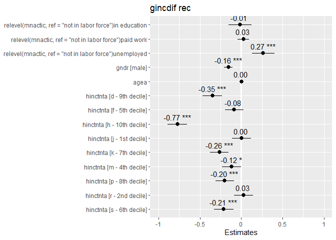

```r
# compare coefficient plots
plot_model(model2, colors = "black", show.values = TRUE, value.offset = .5)
```

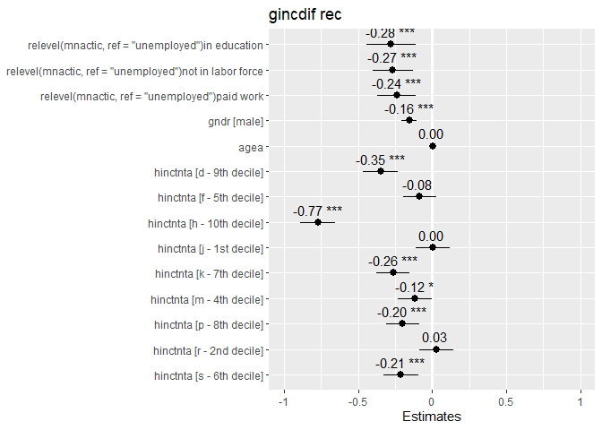

```r
plot_model(model2_alt, colors = "black", show.values = TRUE, value.offset = .5)
```

## 4. Comparing countries

### a) Country differences

Let us compare Germany, Sweden, and the UK. What is the average level of welfare state support in each country?

```r
aggregate(ESS08$gincdif_rec, list(ESS08$cntry), mean, na.rm=TRUE)
```

```
##   Group.1        x
## 1      DE 3.723234
## 2      GB 3.552804
## 3      SE 3.717124
```

### b) Models by country

Run separate models for Germany, Sweden, and the UK to analyze differences in the effects across countries. What do you conclude: Do effects differ across the three welfare states?

Finally, spend some time creating pretty tables for these country-specific models using `tab_model()`. Check out all the possibilities [here](https://strengejacke.github.io/sjPlot/articles/tab_model_estimates.html).

```r
# Turn the original labor market variable into factor
ESS08$mnactic <- relevel(factor(ESS08$mnactic), ref = "not in labor force")

# Germany
model_DE <- lm(gincdif_rec ~ mnactic + gndr + agea + hinctnta,
               data = subset(ESS08, cntry == "DE"))

summary(model_DE)
```

```
##
## Call:
## lm(formula = gincdif_rec ~ mnactic + gndr + agea + hinctnta,
##     data = subset(ESS08, cntry == "DE"))
##
## Residuals:
##     Min      1Q  Median      3Q     Max
## -3.0161 -0.6532  0.1426  0.6814  2.2128
##
## Coefficients:
##                           Estimate Std. Error t value Pr(>|t|)
## (Intercept)              3.9797834  0.1251602  31.798  < 2e-16 ***
## mnacticin education     -0.1470622  0.1173235  -1.253  0.21016
## mnacticpaid work         0.0651257  0.0575614   1.131  0.25800
## mnacticunemployed        0.3230325  0.1018036   3.173  0.00153 **
## gndrmale                -0.1053558  0.0428977  -2.456  0.01413 *
## agea                    -0.0001424  0.0016994  -0.084  0.93323
## hinctntad - 9th decile  -0.7181226  0.1124710  -6.385 2.08e-10 ***
## hinctntaf - 5th decile  -0.0789323  0.0816761  -0.966  0.33395
## hinctntah - 10th decile -1.0418686  0.1225964  -8.498  < 2e-16 ***
## hinctntaj - 1st decile   0.0448946  0.0852444   0.527  0.59848
## hinctntak - 7th decile  -0.5236545  0.0909810  -5.756 9.82e-09 ***
## hinctntam - 4th decile  -0.2124193  0.0790956  -2.686  0.00729 **
## hinctntap - 8th decile  -0.5301767  0.0987074  -5.371 8.63e-08 ***
## hinctntar - 2nd decile  -0.0620222  0.0820251  -0.756  0.44965
## hinctntas - 6th decile  -0.3789727  0.0880475  -4.304 1.75e-05 ***
## ---
## Signif. codes:  0 '***' 0.001 '**' 0.01 '*' 0.05 '.' 0.1 ' ' 1
##
## Residual standard error: 1 on 2231 degrees of freedom
##   (34 Beobachtungen als fehlend gelöscht)
## Multiple R-squared:  0.0835, Adjusted R-squared:  0.07775
## F-statistic: 14.52 on 14 and 2231 DF,  p-value: < 2.2e-16
```

```r
# Sweden
model_SE <- lm(gincdif_rec ~ mnactic + gndr + agea + hinctnta,
     data = subset(ESS08, cntry == "SE"))

summary(model_SE)
```

```
##
## Call:
## lm(formula = gincdif_rec ~ mnactic + gndr + agea + hinctnta,
##     data = subset(ESS08, cntry == "SE"))
##
## Residuals:
##     Min      1Q  Median      3Q     Max
## -2.8310 -0.5939  0.1358  0.5691  1.8627
##
## Coefficients:
##                           Estimate Std. Error t value Pr(>|t|)
## (Intercept)              3.6785809  0.1666419  22.075  < 2e-16 ***
## mnacticin education      0.0006167  0.1271721   0.005  0.99613
## mnacticpaid work        -0.0915260  0.0755376  -1.212  0.22581
## mnacticunemployed        0.1603745  0.1452206   1.104  0.26960
## gndrmale                -0.2263057  0.0441149  -5.130 3.23e-07 ***
## agea                     0.0045272  0.0018103   2.501  0.01249 *
## hinctntad - 9th decile  -0.0934755  0.1191244  -0.785  0.43275
## hinctntaf - 5th decile  -0.0535867  0.1298831  -0.413  0.67997
## hinctntah - 10th decile -0.3320908  0.1223464  -2.714  0.00671 **
## hinctntaj - 1st decile  -0.1343071  0.1629124  -0.824  0.40982
## hinctntak - 7th decile   0.0719362  0.1192348   0.603  0.54638
## hinctntam - 4th decile   0.1577294  0.1377685   1.145  0.25242
## hinctntap - 8th decile   0.1830625  0.1178946   1.553  0.12067
## hinctntar - 2nd decile   0.1423407  0.1449841   0.982  0.32635
## hinctntas - 6th decile   0.0367712  0.1249104   0.294  0.76850
## ---
## Signif. codes:  0 '***' 0.001 '**' 0.01 '*' 0.05 '.' 0.1 ' ' 1
##
## Residual standard error: 0.9045 on 1696 degrees of freedom
##   (19 Beobachtungen als fehlend gelöscht)
## Multiple R-squared:  0.07184,    Adjusted R-squared:  0.06418
## F-statistic: 9.377 on 14 and 1696 DF,  p-value: < 2.2e-16
```

```r
# Great Britain
model_GB <- lm(gincdif_rec ~ mnactic + gndr + agea + hinctnta,
     data = subset(ESS08, cntry == "GB"))

summary(model_GB)
```

```
##
## Call:
## lm(formula = gincdif_rec ~ mnactic + gndr + agea + hinctnta,
##     data = subset(ESS08, cntry == "GB"))
##
## Residuals:
##     Min      1Q  Median      3Q     Max
## -3.0552 -0.7496  0.2138  0.5907  2.2753
##
## Coefficients:
##                          Estimate Std. Error t value Pr(>|t|)
## (Intercept)              3.896164   0.123235  31.616  < 2e-16 ***
## mnacticin education      0.018993   0.142599   0.133  0.89405
## mnacticpaid work        -0.020445   0.062443  -0.327  0.74339
## mnacticunemployed        0.084031   0.127024   0.662  0.50835
## gndrmale                -0.129476   0.047711  -2.714  0.00671 **
## agea                    -0.001981   0.001635  -1.212  0.22581
## hinctntad - 9th decile  -0.236653   0.110722  -2.137  0.03269 *
## hinctntaf - 5th decile  -0.112788   0.110200  -1.023  0.30621
## hinctntah - 10th decile -0.888828   0.101638  -8.745  < 2e-16 ***
## hinctntaj - 1st decile   0.065021   0.099279   0.655  0.51259
## hinctntak - 7th decile  -0.241828   0.102361  -2.363  0.01825 *
## hinctntam - 4th decile  -0.108606   0.105919  -1.025  0.30532
## hinctntap - 8th decile  -0.294621   0.106980  -2.754  0.00594 **
## hinctntar - 2nd decile   0.148325   0.099283   1.494  0.13535
## hinctntas - 6th decile  -0.140418   0.107077  -1.311  0.18989
## ---
## Signif. codes:  0 '***' 0.001 '**' 0.01 '*' 0.05 '.' 0.1 ' ' 1
##
## Residual standard error: 1.03 on 1962 degrees of freedom
##   (19 Beobachtungen als fehlend gelöscht)
## Multiple R-squared:  0.08109,    Adjusted R-squared:  0.07453
## F-statistic: 12.37 on 14 and 1962 DF,  p-value: < 2.2e-16
```

```r
# all in one table
tab_model(model_DE, model_SE, model_GB,
          dv.labels = c("Germany", "Sweden","Great Britain"),
          terms = c("mnactic [in education]", "mnactic [paid work]",
                    "mnactic [unemployed]"),
        #  pred.labels = c("In education", "In paid work", "Unemployed"),
          show.reflvl = TRUE,
          show.se = TRUE,
          collapse.ci = TRUE,
          p.style = "stars",
          digits = 2
          )
```

Germany

Sweden

Great Britain

Predictors

Estimates

std. Error

Estimates

std. Error

Estimates

std. Error

not in labor force

*Reference*

*Reference*

*Reference*

in education

-0.15  
(-0.38 – 0.08)

0.12

0.00  
(-0.25 – 0.25)

0.13

0.02  
(-0.26 – 0.30)

0.14

paid work

0.07  
(-0.05 – 0.18)

0.06

-0.09  
(-0.24 – 0.06)

0.08

-0.02  
(-0.14 – 0.10)

0.06

unemployed

0.32 **  
(0.12 – 0.52)

0.10

0.16  
(-0.12 – 0.45)

0.15

0.08  
(-0.17 – 0.33)

0.13

Observations

2246

1711

1977

R<sup>2</sup> / R<sup>2</sup> adjusted

0.083 / 0.078

0.072 / 0.064

0.081 / 0.075

- p<0.05 ** p<0.01 *** p<0.001